# 1c96fee4-af67-4c6f-bc39-6dcac175a197

### Загрузите данные и подготовьте их к анализу

Загрузите данные о визитах, заказах и рекламных расходах из CSV-файлов в переменные.

**Пути к файлам**

- визиты: `/datasets/visits_info_short.csv`. [Скачать датасет](https://code.s3.yandex.net/datasets/visits_info_short.csv);
- заказы: `/datasets/orders_info_short.csv`. [Скачать датасет](https://code.s3.yandex.net/datasets/orders_info_short.csv);
- расходы: `/datasets/costs_info_short.csv`. [Скачать датасет](https://code.s3.yandex.net/datasets/costs_info_short.csv).

Изучите данные и выполните предобработку. Есть ли в данных пропуски и дубликаты? Убедитесь, что типы данных во всех колонках соответствуют сохранённым в них значениям. Обратите внимание на столбцы с датой и временем.

```python
import pandas as pd
import numpy as np
from datetime import date, datetime, timedelta
from matplotlib import pyplot as plt
```

```python
visits = pd.read_csv('/datasets/visits_info_short.csv') # инфо о посещениях сайта
orders = pd.read_csv('/datasets/orders_info_short.csv') # инфо о заказах
costs = pd.read_csv('/datasets/costs_info_short.csv') # инфо о расходах на рекламу
```

```python
visits.info()
```

```
<class 'pandas.core.frame.DataFrame'>
RangeIndex: 309901 entries, 0 to 309900
Data columns (total 6 columns):
 #   Column         Non-Null Count   Dtype
---  ------         --------------   -----
 0   User Id        309901 non-null  int64
 1   Region         309901 non-null  object
 2   Device         309901 non-null  object
 3   Channel        309901 non-null  object
 4   Session Start  309901 non-null  object
 5   Session End    309901 non-null  object
dtypes: int64(1), object(5)
memory usage: 14.2+ MB
```

Как видим, таблица состоит из 6 столбцов и 309901 строк. Все данные заполнены.

Приведем наименования столбцов к нижнему регистру и изменим тип данных в столбцах с датами, для дальнейшего анализа.

```python
visits.columns = ['user_id', 'region', 'device', 'channel', 'session_start', 'session_end']
```

```python
visits['session_start'] = pd.to_datetime(visits['session_start'])
visits['session_end'] = pd.to_datetime(visits['session_end'])
```

Проверим на наличие явных дубликатов:

```python
print(visits.duplicated().sum())
```

```
0
```

Изучим уникальные значения в столбцах с данными о странах пользователей, типах устройств и идентификаторов источников перехода:

```python
visits['region'].unique()
```

```
array(['United States', 'UK', 'France', 'Germany'], dtype=object)
```

```python
visits['device'].unique()
```

```
array(['iPhone', 'Mac', 'Android', 'PC'], dtype=object)
```

```python
visits['channel'].unique()
```

```
array(['organic', 'TipTop', 'RocketSuperAds', 'YRabbit', 'FaceBoom',
       'MediaTornado', 'AdNonSense', 'LeapBob', 'WahooNetBanner',
       'OppleCreativeMedia', 'lambdaMediaAds'], dtype=object)
```

Аналогично, изучим файл с заказми и расходами на рекламу.

```python
orders.info()
```

```
<class 'pandas.core.frame.DataFrame'>
RangeIndex: 40212 entries, 0 to 40211
Data columns (total 3 columns):
 #   Column    Non-Null Count  Dtype
---  ------    --------------  -----
 0   User Id   40212 non-null  int64
 1   Event Dt  40212 non-null  object
 2   Revenue   40212 non-null  float64
dtypes: float64(1), int64(1), object(1)
memory usage: 942.6+ KB
```

```python
# приведем наименования столбцов в соответствие
orders.columns = ['user_id', 'event_dt', 'revenue']
```

```python
# изменим тип даты
orders['event_dt'] = pd.to_datetime(orders['event_dt'])
```

```python
# проверим на наличие явных дубликатов
print(orders.duplicated().sum())
```

```
0
```

```python
costs.info()
```

```
<class 'pandas.core.frame.DataFrame'>
RangeIndex: 1800 entries, 0 to 1799
Data columns (total 3 columns):
 #   Column   Non-Null Count  Dtype
---  ------   --------------  -----
 0   dt       1800 non-null   object
 1   Channel  1800 non-null   object
 2   costs    1800 non-null   float64
dtypes: float64(1), object(2)
memory usage: 42.3+ KB
```

```python
# приведем наименования столбцов в соответствие
costs.columns = ['dt', 'channel', 'costs']
```

```python
# изменим тип даты
costs['dt'] = pd.to_datetime(costs['dt'])
```

```python
# проверим на наличие явных дубликатов
print(costs.duplicated().sum())
```

```
0
```

```python
costs['channel'].unique()
```

```
array(['FaceBoom', 'MediaTornado', 'RocketSuperAds', 'TipTop', 'YRabbit',
       'AdNonSense', 'LeapBob', 'OppleCreativeMedia', 'WahooNetBanner',
       'lambdaMediaAds'], dtype=object)
```

Итак, на этапе подготовки данных к анализу, мы загрузили три файла с информациями о логах с сервера о посещениях сайта, о заказах и о расходах на рекламу.

Изучили каждый файл и привели наименование столбцов в соответствие.

Убедились, что нет пропусков данных и дубликатов.

Убедились, что типы данных в колонках соответсвуют сохранненным в них значениям и изменили типы данных в столбцах с датой и временем.

### Задайте функции для расчёта и анализа LTV, ROI, удержания и конверсии.

Разрешается использовать функции, с которыми вы познакомились в теоретических уроках.

Это функции для вычисления значений метрик:

- `get_profiles()` — для создания профилей пользователей,
- `get_retention()` — для подсчёта Retention Rate,
- `get_conversion()` — для подсчёта конверсии,
- `get_ltv()` — для подсчёта LTV.

А также функции для построения графиков:

- `filter_data()` — для сглаживания данных,
- `plot_retention()` — для построения графика Retention Rate,
- `plot_conversion()` — для построения графика конверсии,
- `plot_ltv_roi` — для визуализации LTV и ROI.

```python
def get_profiles(sessions, orders, ad_costs):

    # находим параметры первых посещений
    profiles = (
        sessions.sort_values(by=['user_id', 'session_start'])
        .groupby('user_id')
        .agg(
            {
                'session_start': 'first',
                'channel': 'first',
                'device': 'first',
                'region': 'first',
            }
        )
        .rename(columns={'session_start': 'first_ts'})
        .reset_index()
    )

    # для когортного анализа определяем дату первого посещения
    # и первый день месяца, в который это посещение произошло
    profiles['dt'] = profiles['first_ts'].dt.date
    profiles['dt'] = pd.to_datetime(profiles['dt'], format="%Y-%m-%d")
    profiles['month'] = profiles['first_ts'].astype('datetime64[M]')

    # добавляем признак платящих пользователей
    profiles['payer'] = profiles['user_id'].isin(orders['user_id'].unique())


    # считаем количество уникальных пользователей
    # с одинаковыми источником и датой привлечения
    new_users = (
        profiles.groupby(['dt', 'channel'])
        .agg({'user_id': 'nunique'})
        .rename(columns={'user_id': 'unique_users'})
        .reset_index()
    )

    # объединяем траты на рекламу и число привлечённых пользователей
    ad_costs = ad_costs.merge(new_users, on=['dt', 'channel'], how='left')

    # делим рекламные расходы на число привлечённых пользователей
    # результаты сохраним в столбец acquisition_cost (CAC)
    ad_costs['acquisition_cost'] = ad_costs['costs'] / ad_costs['unique_users']

    # добавляем стоимость привлечения в профили
    profiles = profiles.merge(
        ad_costs[['dt', 'channel', 'acquisition_cost']],
        on=['dt', 'channel'],
        how='left',
    )

    # стоимость привлечения органических пользователей равна нулю
    profiles['acquisition_cost'] = profiles['acquisition_cost'].fillna(0)

    return profiles
```

```python
def get_retention(
    profiles,
    sessions,
    observation_date,
    horizon_days,
    dimensions=[],
    ignore_horizon=False,
):

    # добавляем столбец payer в передаваемый dimensions список
    dimensions = ['payer'] + dimensions

    # исключаем пользователей, не «доживших» до горизонта анализа
    last_suitable_acquisition_date = observation_date
    if not ignore_horizon:
        last_suitable_acquisition_date = observation_date - timedelta(
            days=horizon_days - 1
        )
    result_raw = profiles.query('dt <= @last_suitable_acquisition_date')

    # собираем «сырые» данные для расчёта удержания
    result_raw = result_raw.merge(
        sessions[['user_id', 'session_start']], on='user_id', how='left'
    )
    result_raw['lifetime'] = (
        result_raw['session_start'] - result_raw['first_ts']
    ).dt.days

    # функция для группировки таблицы по желаемым признакам
    def group_by_dimensions(df, dims, horizon_days):
        result = df.pivot_table(
            index=dims, columns='lifetime', values='user_id', aggfunc='nunique'
        )
        cohort_sizes = (
            df.groupby(dims)
            .agg({'user_id': 'nunique'})
            .rename(columns={'user_id': 'cohort_size'})
        )
        result = cohort_sizes.merge(result, on=dims, how='left').fillna(0)
        result = result.div(result['cohort_size'], axis=0)
        result = result[['cohort_size'] + list(range(horizon_days))]
        result['cohort_size'] = cohort_sizes
        return result

    # получаем таблицу удержания
    result_grouped = group_by_dimensions(result_raw, dimensions, horizon_days)

    # получаем таблицу динамики удержания
    result_in_time = group_by_dimensions(
        result_raw, dimensions + ['dt'], horizon_days
    )

    # возвращаем обе таблицы и сырые данные
    return result_raw, result_grouped, result_in_time
```

```python
def get_conversion(
    profiles,
    purchases,
    observation_date,
    horizon_days,
    dimensions=[],
    ignore_horizon=False,
):

    # исключаем пользователей, не «доживших» до горизонта анализа
    last_suitable_acquisition_date = observation_date
    if not ignore_horizon:
        last_suitable_acquisition_date = observation_date - timedelta(
            days=horizon_days - 1
        )
    result_raw = profiles.query('dt <= @last_suitable_acquisition_date')

    # определяем дату и время первой покупки для каждого пользователя
    first_purchases = (
        purchases.sort_values(by=['user_id', 'event_dt'])
        .groupby('user_id')
        .agg({'event_dt': 'first'})
        .reset_index()
    )

    # добавляем данные о покупках в профили
    result_raw = result_raw.merge(
        first_purchases[['user_id', 'event_dt']], on='user_id', how='left'
    )

    # рассчитываем лайфтайм для каждой покупки
    result_raw['lifetime'] = (
        result_raw['event_dt'] - result_raw['first_ts']
    ).dt.days

    # группируем по cohort, если в dimensions ничего нет
    if len(dimensions) == 0:
        result_raw['cohort'] = 'All users'
        dimensions = dimensions + ['cohort']

    # функция для группировки таблицы по желаемым признакам
    def group_by_dimensions(df, dims, horizon_days):
        result = df.pivot_table(
            index=dims, columns='lifetime', values='user_id', aggfunc='nunique'
        )
        result = result.fillna(0).cumsum(axis = 1)
        cohort_sizes = (
            df.groupby(dims)
            .agg({'user_id': 'nunique'})
            .rename(columns={'user_id': 'cohort_size'})
        )
        result = cohort_sizes.merge(result, on=dims, how='left').fillna(0)
        # делим каждую «ячейку» в строке на размер когорты
        # и получаем conversion rate
        result = result.div(result['cohort_size'], axis=0)
        result = result[['cohort_size'] + list(range(horizon_days))]
        result['cohort_size'] = cohort_sizes
        return result

    # получаем таблицу конверсии
    result_grouped = group_by_dimensions(result_raw, dimensions, horizon_days)

    # для таблицы динамики конверсии убираем 'cohort' из dimensions
    if 'cohort' in dimensions:
        dimensions = []

    # получаем таблицу динамики конверсии
    result_in_time = group_by_dimensions(
        result_raw, dimensions + ['dt'], horizon_days
    )

    # возвращаем обе таблицы и сырые данные
    return result_raw, result_grouped, result_in_time
```

```python
def get_ltv(
    profiles,  # Шаг 1. Получить профили и данные о покупках
    purchases,
    observation_date,
    horizon_days,
    dimensions=[],
    ignore_horizon=False,
):

    # исключаем пользователей, не «доживших» до горизонта анализа
    last_suitable_acquisition_date = observation_date
    if not ignore_horizon:
        last_suitable_acquisition_date = observation_date - timedelta(
            days=horizon_days - 1
        )
    result_raw = profiles.query('dt <= @last_suitable_acquisition_date')

    # Шаг 2. Добавить данные о покупках в профили

    result_raw = result_raw.merge(
        # добавляем в профили время совершения покупок и выручку
        purchases[['user_id', 'event_dt', 'revenue']],
        on='user_id',
        how='left',
    )

    # Шаг 3. Рассчитать лайфтайм пользователя для каждой покупки
    result_raw['lifetime'] = (
        result_raw['event_dt'] - result_raw['first_ts']
    ).dt.days

    # группируем по cohort, если в dimensions ничего нет
    if len(dimensions) == 0:
        result_raw['cohort'] = 'All users'
        dimensions = dimensions + ['cohort']

    # функция для группировки таблицы по желаемым признакам
    def group_by_dimensions(df, dims, horizon_days):

        # Шаг 4. Построить таблицу выручки
        # строим «треугольную» таблицу
        result = df.pivot_table(
            index=dims,
            columns='lifetime',
            values='revenue',  # в ячейках — выручка за каждый лайфтайм
            aggfunc='sum',
        )

        # Шаг 5. Посчитать сумму выручки с накоплением
        result = result.fillna(0).cumsum(axis=1)

        # Шаг 6. Вычислить размеры когорт
        cohort_sizes = (
            df.groupby(dims)
            .agg({'user_id': 'nunique'})
            .rename(columns={'user_id': 'cohort_size'})
        )

        # Шаг 7. Объединить размеры когорт и таблицу выручки
        result = cohort_sizes.merge(result, on=dims, how='left').fillna(0)

        # Шаг 8. Посчитать LTV
        # делим каждую «ячейку» в строке на размер когорты
        result = result.div(result['cohort_size'], axis=0)
        # исключаем все лайфтаймы, превышающие горизонт анализа
        result = result[['cohort_size'] + list(range(horizon_days))]
        # восстанавливаем размеры когорт
        result['cohort_size'] = cohort_sizes
        # сохраняем в датафрейм данные пользователей и значения CAC,
        # добавив параметры из dimensions
        cac = df[['user_id', 'acquisition_cost'] + dims].drop_duplicates()

        # считаем средний CAC по параметрам из dimensions
        cac = (
            cac.groupby(dims)
            .agg({'acquisition_cost': 'mean'})
            .rename(columns={'acquisition_cost': 'cac'})
        )

        # считаем ROI: делим LTV на CAC
        roi = result.div(cac['cac'], axis=0)

        # удаляем строки с бесконечным ROI
        roi = roi[~roi['cohort_size'].isin([np.inf])]

        # восстанавливаем размеры когорт в таблице ROI
        roi['cohort_size'] = cohort_sizes

        # добавляем CAC в таблицу ROI
        roi['cac'] = cac['cac']

        # в финальной таблице оставляем размеры когорт, CAC
        # и ROI в лайфтаймы, не превышающие горизонт анализа
        roi = roi[['cohort_size', 'cac'] + list(range(horizon_days))]

        # возвращаем таблицы LTV и ROI
        return result, roi

    # получаем таблицы LTV и ROI
    result_grouped, roi_grouped = group_by_dimensions(
        result_raw, dimensions, horizon_days
    )

    # для таблиц динамики убираем 'cohort' из dimensions
    if 'cohort' in dimensions:
        dimensions = []

    # получаем таблицы динамики LTV и ROI
    result_in_time, roi_in_time = group_by_dimensions(
        result_raw, dimensions + ['dt'], horizon_days
    )

    return (
        result_raw,  # сырые данные
        result_grouped,  # таблица LTV
        result_in_time,  # таблица динамики LTV
        roi_grouped,  # таблица ROI
        roi_in_time,  # таблица динамики ROI
    )
```

```python
def filter_data(df, window):
    # для каждого столбца применяем скользящее среднее
    for column in df.columns.values:
        df[column] = df[column].rolling(window).mean()
    return df
```

```python
def plot_retention(retention, retention_history, horizon, window=7):

    # задаём размер сетки для графиков
    plt.figure(figsize=(15, 10))

    # исключаем размеры когорт и удержание первого дня
    retention = retention.drop(columns=['cohort_size', 0])
    # в таблице динамики оставляем только нужный лайфтайм
    retention_history = retention_history.drop(columns=['cohort_size'])[
        [horizon - 1]
    ]

    # если в индексах таблицы удержания только payer,
    # добавляем второй признак — cohort
    if retention.index.nlevels == 1:
        retention['cohort'] = 'All users'
        retention = retention.reset_index().set_index(['cohort', 'payer'])

    # в таблице графиков — два столбца и две строки, четыре ячейки
    # в первой строим кривые удержания платящих пользователей
    ax1 = plt.subplot(2, 2, 1)
    retention.query('payer == True').droplevel('payer').T.plot(
        grid=True, ax=ax1
    )
    plt.legend()
    plt.xlabel('Лайфтайм')
    plt.title('Удержание платящих пользователей')

    # во второй ячейке строим кривые удержания неплатящих
    # вертикальная ось — от графика из первой ячейки
    ax2 = plt.subplot(2, 2, 2, sharey=ax1)
    retention.query('payer == False').droplevel('payer').T.plot(
        grid=True, ax=ax2
    )
    plt.legend()
    plt.xlabel('Лайфтайм')
    plt.title('Удержание неплатящих пользователей')

    # в третьей ячейке — динамика удержания платящих
    ax3 = plt.subplot(2, 2, 3)
    # получаем названия столбцов для сводной таблицы
    columns = [
        name
        for name in retention_history.index.names
        if name not in ['dt', 'payer']
    ]
    # фильтруем данные и строим график
    filtered_data = retention_history.query('payer == True').pivot_table(
        index='dt', columns=columns, values=horizon - 1, aggfunc='mean'
    )
    filter_data(filtered_data, window).plot(grid=True, ax=ax3)
    plt.xlabel('Дата привлечения')
    plt.title(
        'Динамика удержания платящих пользователей на {}-й день'.format(
            horizon
        )
    )

    # в чётвертой ячейке — динамика удержания неплатящих
    ax4 = plt.subplot(2, 2, 4, sharey=ax3)
    # фильтруем данные и строим график
    filtered_data = retention_history.query('payer == False').pivot_table(
        index='dt', columns=columns, values=horizon - 1, aggfunc='mean'
    )
    filter_data(filtered_data, window).plot(grid=True, ax=ax4)
    plt.xlabel('Дата привлечения')
    plt.title(
        'Динамика удержания неплатящих пользователей на {}-й день'.format(
            horizon
        )
    )

    plt.tight_layout()
    plt.show()
```

```python
def plot_conversion(conversion, conversion_history, horizon, window=7):

    # задаём размер сетки для графиков
    plt.figure(figsize=(15, 5))

    # исключаем размеры когорт
    conversion = conversion.drop(columns=['cohort_size'])
    # в таблице динамики оставляем только нужный лайфтайм
    conversion_history = conversion_history.drop(columns=['cohort_size'])[
        [horizon - 1]
    ]

    # первый график — кривые конверсии
    ax1 = plt.subplot(1, 2, 1)
    conversion.T.plot(grid=True, ax=ax1)
    plt.legend()
    plt.xlabel('Лайфтайм')
    plt.title('Конверсия пользователей')

    # второй график — динамика конверсии
    ax2 = plt.subplot(1, 2, 2, sharey=ax1)
    columns = [
        # столбцами сводной таблицы станут все столбцы индекса, кроме даты
        name for name in conversion_history.index.names if name not in ['dt']
    ]
    filtered_data = conversion_history.pivot_table(
        index='dt', columns=columns, values=horizon - 1, aggfunc='mean'
    )
    filter_data(filtered_data, window).plot(grid=True, ax=ax2)
    plt.xlabel('Дата привлечения')
    plt.title('Динамика конверсии пользователей'.format(horizon))

    plt.tight_layout()
    plt.show()
```

```python
def plot_ltv_roi(ltv, ltv_history, roi, roi_history, horizon, window=7):

    # задаём сетку отрисовки графиков
    plt.figure(figsize=(20, 10))

    # из таблицы ltv исключаем размеры когорт
    ltv = ltv.drop(columns=['cohort_size'])
    # в таблице динамики ltv оставляем только нужный лайфтайм
    ltv_history = ltv_history.drop(columns=['cohort_size'])[[horizon - 1]]

    # стоимость привлечения запишем в отдельный фрейм
    cac_history = roi_history[['cac']]

    # из таблицы roi исключаем размеры когорт и cac
    roi = roi.drop(columns=['cohort_size', 'cac'])
    # в таблице динамики roi оставляем только нужный лайфтайм
    roi_history = roi_history.drop(columns=['cohort_size', 'cac'])[
        [horizon - 1]
    ]

    # первый график — кривые ltv
    ax1 = plt.subplot(2, 3, 1)
    ltv.T.plot(grid=True, ax=ax1)
    plt.legend()
    plt.xlabel('Лайфтайм')
    plt.title('LTV')

    # второй график — динамика ltv
    ax2 = plt.subplot(2, 3, 2, sharey=ax1)
    # столбцами сводной таблицы станут все столбцы индекса, кроме даты
    columns = [name for name in ltv_history.index.names if name not in ['dt']]
    filtered_data = ltv_history.pivot_table(
        index='dt', columns=columns, values=horizon - 1, aggfunc='mean'
    )
    filter_data(filtered_data, window).plot(grid=True, ax=ax2)
    plt.xlabel('Дата привлечения')
    plt.title('Динамика LTV пользователей на {}-й день'.format(horizon))

    # третий график — динамика cac
    ax3 = plt.subplot(2, 3, 3, sharey=ax1)
    # столбцами сводной таблицы станут все столбцы индекса, кроме даты
    columns = [name for name in cac_history.index.names if name not in ['dt']]
    filtered_data = cac_history.pivot_table(
        index='dt', columns=columns, values='cac', aggfunc='mean'
    )
    filter_data(filtered_data, window).plot(grid=True, ax=ax3)
    plt.xlabel('Дата привлечения')
    plt.title('Динамика стоимости привлечения пользователей')

    # четвёртый график — кривые roi
    ax4 = plt.subplot(2, 3, 4)
    roi.T.plot(grid=True, ax=ax4)
    plt.axhline(y=1, color='red', linestyle='--', label='Уровень окупаемости')
    plt.legend()
    plt.xlabel('Лайфтайм')
    plt.title('ROI')

    # пятый график — динамика roi
    ax5 = plt.subplot(2, 3, 5, sharey=ax4)
    # столбцами сводной таблицы станут все столбцы индекса, кроме даты
    columns = [name for name in roi_history.index.names if name not in ['dt']]
    filtered_data = roi_history.pivot_table(
        index='dt', columns=columns, values=horizon - 1, aggfunc='mean'
    )
    filter_data(filtered_data, window).plot(grid=True, ax=ax5)
    plt.axhline(y=1, color='red', linestyle='--', label='Уровень окупаемости')
    plt.xlabel('Дата привлечения')
    plt.title('Динамика ROI пользователей на {}-й день'.format(horizon))

    plt.tight_layout()
    plt.show()
```

Итак, на втором шаге нашего исследования мы определили функции, с которыми познакомились в теоретических уроках.

Это функции для вычисления значений метрик: get_profiles() — для создания профилей пользователей, get_retention() — для подсчёта Retention Rate, get_conversion() — для подсчёта конверсии, get_ltv() — для подсчёта LTV.

А также функции для построения графиков: filter_data() — для сглаживания данных, plot_retention() — для построения графика Retention Rate, plot_conversion() — для построения графика конверсии, plot_ltv_roi — для визуализации LTV и ROI.

### Исследовательский анализ данных

- Составьте профили пользователей. Определите минимальную и максимальную даты привлечения пользователей.
- Выясните, из каких стран пользователи приходят в приложение и на какую страну приходится больше всего платящих пользователей. Постройте таблицу, отражающую количество пользователей и долю платящих из каждой страны.
- Узнайте, какими устройствами пользуются клиенты и какие устройства предпочитают платящие пользователи. Постройте таблицу, отражающую количество пользователей и долю платящих для каждого устройства.
- Изучите рекламные источники привлечения и определите каналы, из которых пришло больше всего платящих пользователей. Постройте таблицу, отражающую количество пользователей и долю платящих для каждого канала привлечения.

После каждого пункта сформулируйте выводы.

```python
profiles = get_profiles(visits, orders, costs)
profiles.head(10)
```

|  | user_id | first_ts | channel | device | region | dt | month | payer | acquisition_cost |
| --- | --- | --- | --- | --- | --- | --- | --- | --- | --- |
| 0 | 599326 | 2019-05-07 20:58:57 | FaceBoom | Mac | United States | 2019-05-07 | 2019-05-01 | True | 1.088172 |
| 1 | 4919697 | 2019-07-09 12:46:07 | FaceBoom | iPhone | United States | 2019-07-09 | 2019-07-01 | False | 1.107237 |
| 2 | 6085896 | 2019-10-01 09:58:33 | organic | iPhone | France | 2019-10-01 | 2019-10-01 | False | 0.000000 |
| 3 | 22593348 | 2019-08-22 21:35:48 | AdNonSense | PC | Germany | 2019-08-22 | 2019-08-01 | False | 0.988235 |
| 4 | 31989216 | 2019-10-02 00:07:44 | YRabbit | iPhone | United States | 2019-10-02 | 2019-10-01 | False | 0.230769 |
| 5 | 34186288 | 2019-05-09 17:29:23 | organic | Android | United States | 2019-05-09 | 2019-05-01 | False | 0.000000 |
| 6 | 38448301 | 2019-08-16 11:56:00 | organic | Android | United States | 2019-08-16 | 2019-08-01 | False | 0.000000 |
| 7 | 46006712 | 2019-06-30 03:46:29 | AdNonSense | Android | France | 2019-06-30 | 2019-06-01 | True | 1.008000 |
| 8 | 58263264 | 2019-05-11 19:18:43 | FaceBoom | iPhone | United States | 2019-05-11 | 2019-05-01 | False | 1.128205 |
| 9 | 59835779 | 2019-05-11 21:13:47 | MediaTornado | iPhone | United States | 2019-05-11 | 2019-05-01 | False | 0.250435 |

```python
# Составьте профили пользователей. Определите минимальную и максимальную даты привлечения пользователей

profiles['dt'] = profiles['first_ts'].dt.date
min_date = profiles['dt'].min()
max_date = profiles['dt'].max()
print('Минимальная дата привлечения пользователей', min_date)
print('Максимальная дата привлечения пользователей', max_date)
```

```
Минимальная дата привлечения пользователей 2019-05-01
Максимальная дата привлечения пользователей 2019-10-27
```

```python
# из каких стран пользователи приходят в приложение
all=profiles.groupby('region')['user_id'].count()
print(all)
```

```
region
France            17450
Germany           14981
UK                17575
United States    100002
Name: user_id, dtype: int64
```

Лидирующей страной, из которой пользователи приходят в проложение, является США. Более 100 тыс пользователей. При этом с большим отрывом идут Франция и Великобритания, 17450 и 17575 посетителей, соответственно, и Германия - 14981 посетителей.

```python
# на какую страну приходится больше всего платящих пользователей
all_pay= profiles.query('payer == True').groupby('region')['user_id'].count()
print(all_pay)
```

```
region
France            663
Germany           616
UK                700
United States    6902
Name: user_id, dtype: int64
```

Платящие пользователи все-также приходят из США. Но их уже 6902 пользователя. А вот второе место пришлось на покупателей из Великобритании - это 700 покупателей. Третее место разделили Франция и Германия, по +600 покупателей.

```python
# доля платящих из каждой страны
ratio = 100*all_pay/all
print(ratio)
```

```
region
France           3.799427
Germany          4.111875
UK               3.982930
United States    6.901862
Name: user_id, dtype: float64
```

При этом, в долевом решении, США, бесспорно, так и остается в лидерах и доля платящих покупателей соствляет 6,90%. А вот "серебро" достается Германии - 4.11% доля платящих покупателей, против французов и великобританцев.

```python
data = pd.DataFrame()
data['all']=all
data['all_pay']=all_pay
data['ratio']=ratio
print(data.sort_values(by='ratio'))
```

```
                  all  all_pay     ratio
region
France          17450      663  3.799427
UK              17575      700  3.982930
Germany         14981      616  4.111875
United States  100002     6902  6.901862
```

Оформили общий результат исследования в общую таблицу и отсортировали по возрастанию доли платящих покупателей в стране (Франция, Великобритания, Германия, США).

```python
# какими устройствами пользуются клиенты
all1=profiles.groupby('device')['user_id'].count()
print(all1)
```

```
device
Android    35032
Mac        30042
PC         30455
iPhone     54479
Name: user_id, dtype: int64
```

```python
# какие устройства предпочитают платящие пользователи
all1_pay = profiles.query('payer == True').groupby('device')['user_id'].count()
print(all1_pay)
```

```
device
Android    2050
Mac        1912
PC         1537
iPhone     3382
Name: user_id, dtype: int64
```

```python
# доля платящих из каждого устройства
ratio1= 100*all1_pay/all1
ratio1
```

```
device
Android    5.851793
Mac        6.364423
PC         5.046790
iPhone     6.207897
Name: user_id, dtype: float64
```

А вот в процентном соотношении, мы видим, что доля платящих с Мас выше остальных (6,36%), только потом следует iPhone (6,20%), Android (5,85%) и РС (5,05%).

```python
data1 = pd.DataFrame()
data1['all1']=all1
data1['all1_pay']=all1_pay
data1['ratio1']=ratio1
print(data1.sort_values(by='ratio1'))
```

```
          all1  all1_pay    ratio1
device
PC       30455      1537  5.046790
Android  35032      2050  5.851793
iPhone   54479      3382  6.207897
Mac      30042      1912  6.364423
```

Оформили итоговый результат в таблицу и отсортивровали по возрастанию доли платящих для каждого устройства (РС, Android, iPhone, Мас).

```python
# рекламные источники привлечения
profiles['channel'].unique()
```

```
array(['FaceBoom', 'organic', 'AdNonSense', 'YRabbit', 'MediaTornado',
       'RocketSuperAds', 'LeapBob', 'TipTop', 'WahooNetBanner',
       'OppleCreativeMedia', 'lambdaMediaAds'], dtype=object)
```

```python
# определим каналы, из которых пришли покупатели
all2=profiles.groupby('channel')['user_id'].count()
all2
```

```
channel
AdNonSense             3880
FaceBoom              29144
LeapBob                8553
MediaTornado           4364
OppleCreativeMedia     8605
RocketSuperAds         4448
TipTop                19561
WahooNetBanner         8553
YRabbit                4312
lambdaMediaAds         2149
organic               56439
Name: user_id, dtype: int64
```

"Тройку" каналов-лидеров состовили: organic (56439 клиентов), FaceBoom (29144 клиентов) и TipTop (19561 клиент).

```python
# определим каналы, из которых пришло больше всего платящих покупателей
all2_pay = profiles.query('payer == True').groupby('channel')['user_id'].count()
all2_pay
```

```
channel
AdNonSense             440
FaceBoom              3557
LeapBob                262
MediaTornado           156
OppleCreativeMedia     233
RocketSuperAds         352
TipTop                1878
WahooNetBanner         453
YRabbit                165
lambdaMediaAds         225
organic               1160
Name: user_id, dtype: int64
```

Тройка лиеров осталась та же, но сменился порядок. Каналом-лидером, привлекшим больше всего платящих клиентов, стал FaceBoom (3557 клиентов). TipTop привлек 1878 клиентов, а organic - 1160.

```python
# доля платящих для каждого канала привлечений
ratio2=100*all2_pay/all2
ratio2
```

```
channel
AdNonSense            11.340206
FaceBoom              12.204914
LeapBob                3.063253
MediaTornado           3.574702
OppleCreativeMedia     2.707728
RocketSuperAds         7.913669
TipTop                 9.600736
WahooNetBanner         5.296387
YRabbit                3.826531
lambdaMediaAds        10.469986
organic                2.055316
Name: user_id, dtype: float64
```

В долевой характеристики также лидерует канал FaceBoom, далее идут каналы AdNonSense и lambdaMediaAds.

```python
data2 = pd.DataFrame()
data2['all2']=all2
data2['all2_pay']=all2_pay
data2['ratio2']=ratio2
print(data2.sort_values(by='ratio2'))
```

```
                     all2  all2_pay     ratio2
channel
organic             56439      1160   2.055316
OppleCreativeMedia   8605       233   2.707728
LeapBob              8553       262   3.063253
MediaTornado         4364       156   3.574702
YRabbit              4312       165   3.826531
WahooNetBanner       8553       453   5.296387
RocketSuperAds       4448       352   7.913669
TipTop              19561      1878   9.600736
lambdaMediaAds       2149       225  10.469986
AdNonSense           3880       440  11.340206
FaceBoom            29144      3557  12.204914
```

Оформили общий результат в таблицу, отражающую количество пользователей и долю платящих для каждого канала привлечений. Расположили в порядке возрастания доли.

### Маркетинг

- Посчитайте общую сумму расходов на маркетинг.
- Выясните, как траты распределены по рекламным источникам, то есть сколько денег потратили на каждый источник.
- Постройте визуализацию динамики изменения расходов во времени (по неделям и месяцам) по каждому источнику. Постарайтесь отразить это на одном графике.
- Узнайте, сколько в среднем стоило привлечение одного пользователя (CAC) из каждого источника. Используйте профили пользователей.

Напишите промежуточные выводы.

```python
# общая сумма расходов на маркетинг
print("Общая сумма расходов на маркетинг составила:", costs['costs'].sum().round())
```

```
Общая сумма расходов на маркетинг составила: 105497.0
```

```python
# распределение трат по рекламным источникам
print(costs.groupby('channel')['costs'].sum())
```

```
channel
AdNonSense             3911.25
FaceBoom              32445.60
LeapBob                1797.60
MediaTornado            954.48
OppleCreativeMedia     2151.25
RocketSuperAds         1833.00
TipTop                54751.30
WahooNetBanner         5151.00
YRabbit                 944.22
lambdaMediaAds         1557.60
Name: costs, dtype: float64
```

Больше всего средств вложено в рекламный источник TipTop (54751.00), далее 32445.00 потрачено на FaceBoom. Именно эти два рекламных канала заняли 82,65% от общей суммы расходов на маркетинг.

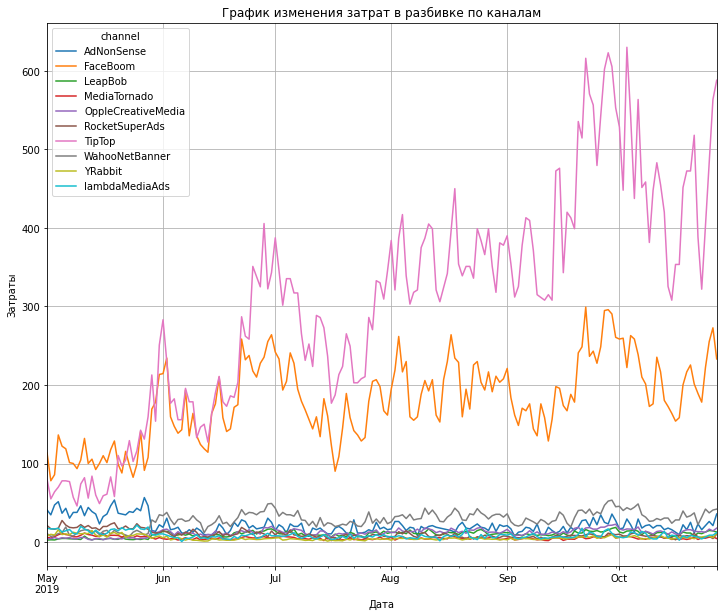

```python
# динамики изменения расходов во времени по каждому источнику
data3 = costs.pivot_table(index='dt', columns='channel', values='costs', aggfunc='sum')
data3.plot(figsize=(12, 10), grid=True,)
plt.title('График изменения затрат в разбивке по каналам')
plt.xlabel('Дата')
plt.ylabel('Затраты')
plt.show()
```

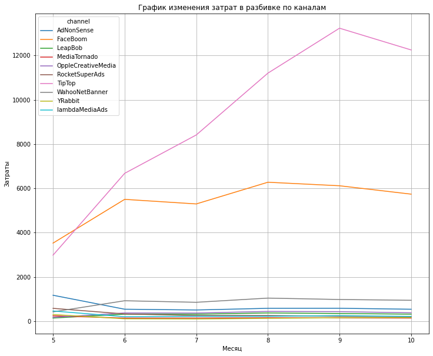

```python
costs['month'] = pd.to_datetime(costs['dt']).dt.month
data4 = costs.pivot_table(index='month', columns='channel', values='costs', aggfunc='sum')
data4.plot(figsize=(12, 10), grid=True,)
plt.title('График изменения затрат в разбивке по каналам')
plt.xlabel('Месяц')
plt.ylabel('Затраты')
plt.show()
```

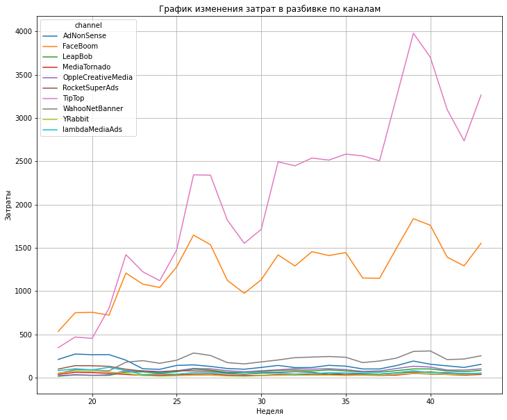

```python
costs['week'] = pd.to_datetime(costs['dt']).dt.week
data4 = costs.pivot_table(index='week', columns='channel', values='costs', aggfunc='sum')
data4.plot(figsize=(12, 10), grid=True,)
plt.title('График изменения затрат в разбивке по каналам')
plt.xlabel('Неделя')
plt.ylabel('Затраты')
plt.show()
```

Графики доказывают нам то, что мы уже увидели на цифрах. Затраты на рекламу росли только для двух каналов TipTop и FaceBoom.

```python
# CAC на одного пользователя из каждого источника
profiles.groupby('channel')['acquisition_cost'].mean()
```

```
channel
AdNonSense            1.008054
FaceBoom              1.113286
LeapBob               0.210172
MediaTornado          0.218717
OppleCreativeMedia    0.250000
RocketSuperAds        0.412095
TipTop                2.799003
WahooNetBanner        0.602245
YRabbit               0.218975
lambdaMediaAds        0.724802
organic               0.000000
Name: acquisition_cost, dtype: float64
```

Как видим, канал organic можно исключить из дальнейшего исследования.

```python
profiles = profiles.query('channel != "organic"')
```

```python
mean_channel=profiles.groupby('channel')['acquisition_cost'].mean().sort_values()
mean_channel
```

```
channel
LeapBob               0.210172
MediaTornado          0.218717
YRabbit               0.218975
OppleCreativeMedia    0.250000
RocketSuperAds        0.412095
WahooNetBanner        0.602245
lambdaMediaAds        0.724802
AdNonSense            1.008054
FaceBoom              1.113286
TipTop                2.799003
Name: acquisition_cost, dtype: float64
```

```python
mean_channel.mean()
```

```
0.7557348976115401
```

Основные затраты пришлись на TipTop, FaceBoom, AdNonSense.

Возможно стоило бы обратить на них внимание и сократить такие высокие расходы, переключив внимание на развитие каналов с минимальными расходами на привлечение клиентов.